# Re-analysis of Muir et al. data

Eric R. Scott

```r
library(tidyverse)
library(here)
library(ropls)
library(glue)
library(colorspace)
library(ggrepel)
source(here("R", "ropls_helpers.R"))
```

# 1 Read in Data

I’m going to remove the outlier species, *S. juglandifolium* for the sake of this analysis

```r
tomato <- read_rds(here("data", "tomatoes.rds"))

#remove S.juglandifolium
tomato.filtered <-
  tomato %>%
  filter(Spe != "jug") %>%
  mutate(temp = temp * 0.1)
```

# 2 PCA

```r
tom.pca2 <- opls(tomato.filtered %>% dplyr::select(lma.leaflet:Rdark), plotL = FALSE)
```

```
PCA
65 samples x 9 variables
standard scaling of predictors
4 (1%) NAs
```

|  | R2X(cum) | pre | ort |
| --- | --- | --- | --- |
| Total | 0.558 | 2 | 0 |

## 2.1 Score plot:

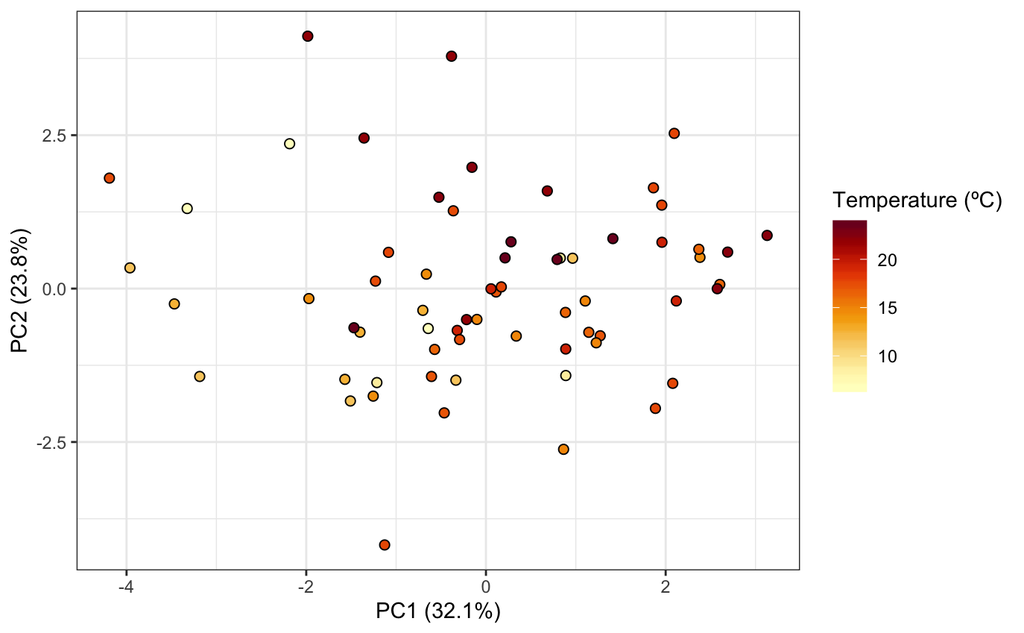

```r
tom.pca2.data <- get_plotdata(tom.pca2)
ggplot(tom.pca2.data$scores, aes(x = p1, y = p2)) +
  geom_point(aes(fill = tomato.filtered$temp), shape = 21, size = 2) +
  scale_color_continuous_sequential("YlOrRd", aesthetics = "fill",
                                    name = "Temperature (ºC)") +
  labs(x = glue("PC1 ({tom.pca2.data$axis_stats[1,1] * 100}%)"),
       y = glue("PC2 ({tom.pca2.data$axis_stats[2,1] * 100}%)")) +
  theme_bw()
```

## 2.2 Correlation plot

PC1 is the leaf economics spectrum

```r
pca.scores <- get_scores(tom.pca2)

pca.data <-
  tom.pca2@suppLs$xModelMN %>%
  as_tibble()

pca.cor.dat <-
  cor(pca.scores[2:3], pca.data, use = "pairwise.complete.obs") %>%
    t() %>%
    as_tibble(rownames = "variable") %>%
  rowwise() %>%
  mutate(distance = sqrt(sum((c(p1, p2) - c(0, 0))^2))) %>%
  ungroup %>%
  mutate(t = distance * sqrt((65-2)/(1-distance^2))) %>%
  mutate(p.dist = pt(t, df = 65-2, lower.tail = FALSE)) %>%
  mutate(p.adj = p.adjust(p.dist, method = "bonf"))
# pca.cor.dat
```

[figure not shown]

```r
pca.loading.plot <-
  ggplot(pca.cor.dat) +
  geom_segment(aes(x = 0, y = 0, xend = p1, yend = p2),
               arrow = arrow(length = unit(0.15, "cm"))) +
  # gghighlight(p.adj < 0.05, use_direct_label = FALSE) +
  geom_label_repel(aes(x = p1, y = p2, label = variable),
                   segment.alpha = 0.6, direction = "y", size = 2.7,
                   min.segment.length = 0, force = 3) +
  theme_bw() +
  labs(x = "Correlation to PC1",
       y = "Correlation to PC2")
pca.loading.plot
```

# 3 PCA regression

Temperature, but not precipitation, is significantly related to PC1 (i.e. the LES)

```r
pcr.df2 <-
  tom.pca2.data$scores %>%
  add_column(temp = tomato.filtered$temp, precip = tomato.filtered$precip)
```

```r
pcr2.temp <- lm(temp ~ p1, data = pcr.df2)
pcr2.precip <- lm(precip ~ p1, data = pcr.df2)
pcr2.temp.a <- lm(temp ~ -1 + p1, data = pcr.df2)
pcr2.precip.a <- lm(precip ~ -1 + p1, data = pcr.df2)
summary(pcr2.temp.a)
```

```
Call:
lm(formula = temp ~ -1 + p1, data = pcr.df2)

Residuals:
   Min     1Q Median     3Q    Max
 7.309 14.088 15.934 19.347 24.992

Coefficients:
   Estimate Std. Error t value Pr(>|t|)
p1   0.9474     1.2810    0.74    0.462

Residual standard error: 17.35 on 64 degrees of freedom
Multiple R-squared:  0.008474,  Adjusted R-squared:  -0.007018
F-statistic: 0.547 on 1 and 64 DF,  p-value: 0.4623
```

```r
summary(pcr2.precip.a)
```

```
Call:
lm(formula = precip ~ -1 + p1, data = pcr.df2)

Residuals:
    Min      1Q  Median      3Q     Max
 -68.58   61.04  572.72  860.37 1362.17

Coefficients:
   Estimate Std. Error t value Pr(>|t|)
p1    35.21      49.31   0.714    0.478

Residual standard error: 667.6 on 64 degrees of freedom
Multiple R-squared:  0.007903,  Adjusted R-squared:  -0.007599
F-statistic: 0.5098 on 1 and 64 DF,  p-value: 0.4778
```

```r
car::Anova(pcr2.precip)
```

```
Anova Table (Type II tests)

Response: precip
            Sum Sq Df F value Pr(>F)
p1          227237  1  1.2211 0.2733
Residuals 11723696 63
```

```r
car::Anova(pcr2.temp)
```

```
Anova Table (Type II tests)

Response: temp
           Sum Sq Df F value   Pr(>F)
p1         164.56  1  9.0677 0.003741 **
Residuals 1143.31 63
---
Signif. codes:  0 ‘***’ 0.001 ‘**’ 0.01 ‘*’ 0.05 ‘.’ 0.1 ‘ ’ 1
```

# 4 PLSR

Both precipitation **and** temperature are significantly related to leaf traits (but temperature has a much lower RMSEE). They explain very little of the variation in the data (`R2X(cum)`), but a significant ammount of variation with the Y variables (`R2Y(cum)` and `pR2Y` and `pQ2`). `Q2(cum)` is not much lower than R2Y indicating an absence of overfitting or a predictive power similar to the explanatory power.

```r
plsr2.precip <-
  opls(tomato.filtered %>% dplyr::select(lma.leaflet:Rdark), tomato.filtered$precip, plotL = FALSE, permI = 1000)
```

```
PLS
65 samples x 9 variables and 1 response
standard scaling of predictors and response(s)
4 (1%) NAs
```

|  | R2X(cum) | R2Y(cum) | Q2(cum) | RMSEE | pre | ort | pR2Y | pQ2 |
| --- | --- | --- | --- | --- | --- | --- | --- | --- |
| Total | 0.199 | 0.421 | 0.336 | 331 | 1 | 0 | 0.001 | 0.001 |

```r
# single component model

plsr2.temp <-
  opls(tomato.filtered %>% dplyr::select(lma.leaflet:Rdark), tomato.filtered$temp, plotL = FALSE, permI = 1000)
```

```
PLS
65 samples x 9 variables and 1 response
standard scaling of predictors and response(s)
4 (1%) NAs
```

|  | R2X(cum) | R2Y(cum) | Q2(cum) | RMSEE | pre | ort | pR2Y | pQ2 |
| --- | --- | --- | --- | --- | --- | --- | --- | --- |
| Total | 0.265 | 0.407 | 0.346 | 3.51 | 1 | 0 | 0.001 | 0.001 |

View outputs in a table

| Model | R2X(cum) | R2Y(cum) | Q2(cum) | pR2Y | pQ2 |
| --- | --- | --- | --- | --- | --- |
| Precipitation ~ leaf traits | 0.199 | 0.421 | 0.336 | 0.001 | 0.001 |
| Temperature ~ leaf traits | 0.265 | 0.407 | 0.346 | 0.001 | 0.001 |

# 5 Compare Loadings

Table of PCA loadings and PLS axis loadings.

| Variable | PC1 | PC2 | Precipitation PLS | Precipitation VIP | Temperature PLS | Temperature VIP |
| --- | --- | --- | --- | --- | --- | --- |
| lma.leaflet | 0.337 | 0.033 | 0.738 | 2.013 | 0.190 | 0.289 |
| thick.vile | 0.199 | -0.334 | 0.394 | 0.757 | -0.147 | 0.773 |
| ldmc | 0.238 | 0.337 | 0.567 | 1.755 | 0.374 | 1.132 |
| A | -0.523 | 0.174 | 0.012 | 0.401 | -0.430 | 1.025 |
| Vcmax | -0.408 | -0.307 | 0.081 | 0.818 | -0.571 | 1.468 |
| gs | -0.266 | 0.546 | -0.007 | 0.027 | -0.064 | 0.165 |
| gm | -0.494 | 0.037 | -0.034 | 0.217 | -0.401 | 0.826 |
| wue | -0.189 | -0.567 | -0.030 | 0.075 | -0.344 | 0.733 |
| Rdark | 0.013 | -0.167 | 0.265 | 0.641 | -0.328 | 1.608 |

It looks like maybe the Temperature PLS axis loadings are more similar to PC1, which makes sense because only the PCA regression for temperature was significant.

# 6 PLSR with two response variables (both precip and temp)

Temp and precip aren’t correlated, so this probably isn’t useful. That fact might be good justification for doing both separately though.

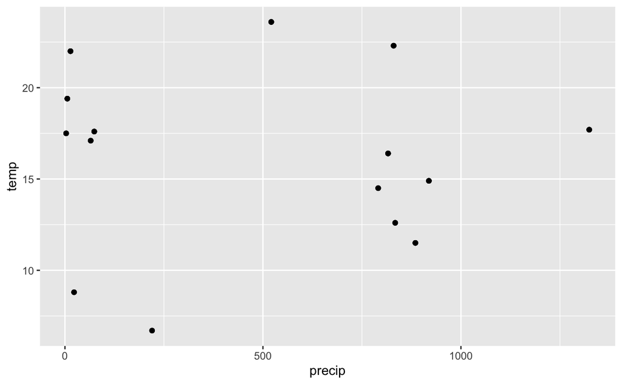

```r
ggplot(tomato.filtered, aes(x = precip, y = temp)) +
  geom_point()
```

```r
cor.test(tomato.filtered$temp, tomato.filtered$precip)
```

```
    Pearson's product-moment correlation

data:  tomato.filtered$temp and tomato.filtered$precip
t = -0.80995, df = 63, p-value = 0.421
alternative hypothesis: true correlation is not equal to 0
95 percent confidence interval:
 -0.3370706  0.1459967
sample estimates:
       cor
-0.1015173
```

Intermediate RMSEE. OK R2Y and Q2. No p-value with this method.

```r
plsr.both <-
  opls(tomato.filtered %>% dplyr::select(lma.leaflet:Rdark), tomato.filtered %>% dplyr::select(temp, precip) %>% as.matrix(), plotL = FALSE, permI = 200)
```

```
PLS
65 samples x 9 variables and 2 responses
standard scaling of predictors and response(s)
4 (1%) NAs
```

|  | R2X(cum) | R2Y(cum) | Q2(cum) | RMSEE | pre | ort |
| --- | --- | --- | --- | --- | --- | --- |
| Total | 0.462 | 0.438 | 0.313 | 225 | 2 | 0 |

```r
getLoadingMN(plsr.both)
```

```
                     p1         p2
lma.leaflet -0.04746512  0.7095282
thick.vile  -0.27539583  0.3090945
ldmc         0.19234739  0.6076452
A           -0.43589909 -0.1618899
Vcmax       -0.60470060 -0.1269281
gs          -0.05887738 -0.0344778
gm          -0.38750130 -0.2105131
wue         -0.33506445 -0.1721055
Rdark       -0.39399545  0.1231519
```

```r
plsr.both@cMN
```

```
               p1        p2
temp    0.4440693 0.1002204
precip -0.1938319 0.4670844
```

P1 is related to temperature, P2 is related to precipitation. This supports doing separate PLS for precipitation and temperature